# Homework3

Brand, Sadr, Taroni, Zagatti

27/5/2020

# Chapter 6

## Exercise 6

**The following investigates the consequences of not using a logarithmic transformation for the nihills data analysis. The second differs from the first in having a dist×climb interaction term, additional to linear terms in dist and climb.**

### a)

Fit the two models:

```r
library(DAAG)
```

```r
nihills.lm <- lm(time ~ dist+climb, data=nihills)
nihills2.lm <- lm(time ~ dist+climb+dist*climb, data=nihills)
anova(nihills.lm, nihills2.lm)
```

```
## Analysis of Variance Table
##
## Model 1: time ~ dist + climb
## Model 2: time ~ dist + climb + dist * climb
##   Res.Df      RSS Df Sum of Sq      F    Pr(>F)
## 1     20 0.189361
## 2     19 0.039361  1      0.15 72.406 6.623e-08 ***
## ---
## Signif. codes:  0 '***' 0.001 '**' 0.01 '*' 0.05 '.' 0.1 ' ' 1
```

We can see that the F statistic is high enough, i.e. the p-value associated to it is low enough, to say that our second model, the one with the interaction term, fits our data better than the first one.

### b)

**Using the F-test result, make a tentative choice of model, and proceed to examine diagnostic plots. Are there any problematic observations? What happens if these points are removed? Refit both of the above models, and check the diagnostics again.**

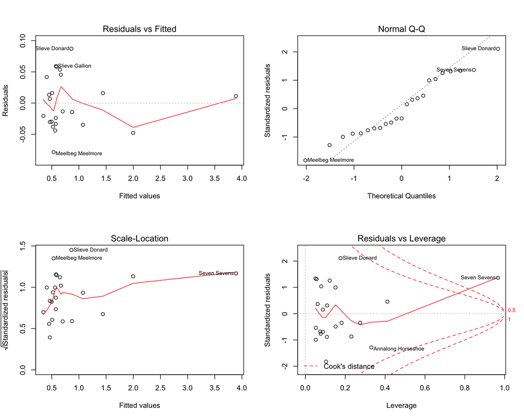

```r
par(mfrow=c(2,2))
plot(nihills2.lm)
```

We can see that “Seven sevens” is a highly influencial point, let’s try to remove it.

```r
nihills.ss <- nihills[!row.names(nihills) %in% "Seven Sevens",]
nihills.ss.lm <- lm(time ~ dist+climb, data=nihills.ss)
nihills2.ss.lm <- lm(time ~ dist+climb+dist*climb, data=nihills.ss)
anova(nihills.ss.lm, nihills2.ss.lm)
```

```
## Analysis of Variance Table
##
## Model 1: time ~ dist + climb
## Model 2: time ~ dist + climb + dist * climb
##   Res.Df      RSS Df Sum of Sq      F Pr(>F)
## 1     19 0.040533
## 2     18 0.035509  1 0.0050248 2.5472 0.1279
```

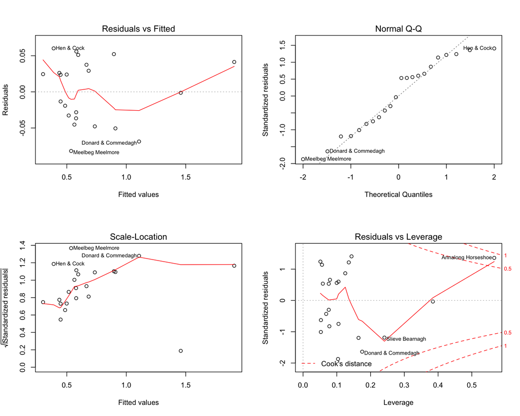

```r
par(mfrow=c(2,2))
plot(nihills.ss.lm)
```

The F statistic of the more complex model is now not so favourable with respect to its most simpler counterpart. In fact, by analyzing the diagnostic plots returned by the first model we notice that the normality assumptions are now slightly better without that point. We could go further and exclude other highly influencial points according to Cook’s distance.

```r
to_rm <- c("Hen & Cock", "Annalong Horseshoe")
nihills.th <- nihills.ss[!row.names(nihills.ss) %in% to_rm,]
nihills.th.lm <- lm(time ~ dist+climb, data=nihills.th)
nihills2.th.lm <- lm(time ~ dist+climb+dist*climb, data=nihills.th)
anova(nihills.th.lm, nihills2.th.lm) #Now the f statistic is pretty bad
```

```
## Analysis of Variance Table
##
## Model 1: time ~ dist + climb
## Model 2: time ~ dist + climb + dist * climb
##   Res.Df      RSS Df  Sum of Sq      F Pr(>F)
## 1     17 0.032865
## 2     16 0.032501  1 0.00036396 0.1792 0.6777
```

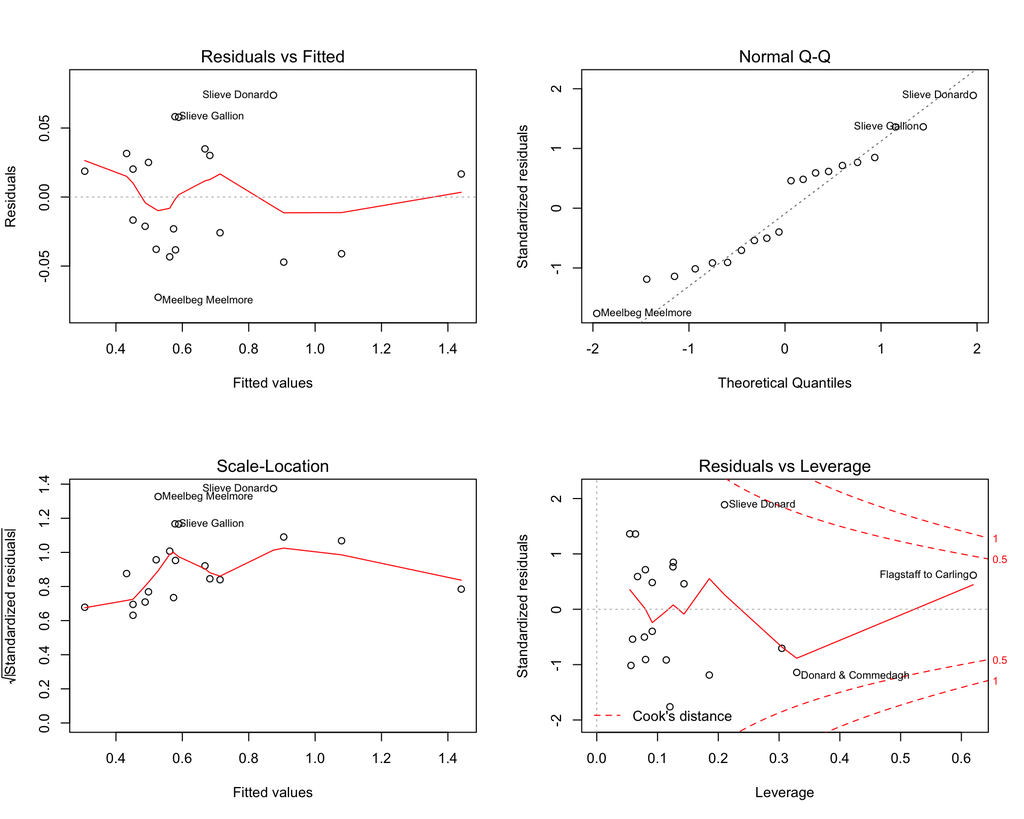

```r
par(mfrow=c(2,2))
plot(nihills.th.lm)
```

Now the F statistic is straight up bad, and the first model is probably better than the second one. The residual don’t present clear cut proof of eteroscedasticity or non-normality.

## Exercise 8:

**Apply the `lm.ridge()` function to the `litters` data, using the generalized cross-validation (GCV) criterion to choose the tuning parameter. (GCV is an approximation to cross-validation.)**

**(a) In particular, estimate the coefficients of the model relating `brainwt` to `bodywt` and `lsize` and compare with the results obtained using `lm()`.**

**(b) Using both ridge and ordinary regression, estimate the mean brain weight when litter size is 10 and body weight is 7. Use the bootstrap, with case-resampling, to compute approximate 95% percentile confidence intervals using each method. Compare with the interval obtained using `predict.lm()`.**

1. Let’s compute the estimates of the coefficients of the model using both `lm` and `lm.ridge`. In the case of `lm.ridge` the GCV criterion to select thd tuning parameter.

```r
library(DAAG)
library(MASS)
library(boot)
```

```r
data <- litters
lsize <- litters$lsize
bodywt <- litters$bodywt
brainwt <- litters$brainwt
# linear model
litters.lm <- lm(brainwt ~ bodywt+lsize, data=litters)
# coefficients of the linear model
summary(litters.lm)$coefficients
```

```
##                Estimate  Std. Error  t value    Pr(>|t|)
## (Intercept) 0.178246962 0.075322590 2.366448 0.030097278
## bodywt      0.024306344 0.006778653 3.585719 0.002278441
## lsize       0.006690331 0.003132075 2.136070 0.047513226
```

```r
# ridge regression using GCV
select(lm.ridge(brainwt ~ bodywt+lsize, data=litters, lambda = seq(0,1,0.001)))
```

```
## modified HKB estimator is 0
## modified L-W estimator is 0
## smallest value of GCV  at 0.118
```

```r
litters.ridge.sel <- lm.ridge(brainwt ~ bodywt+lsize, data=litters, lambda =0.118)
# coefficients of ridge regression
litters.ridge.sel
```

```
##                  bodywt       lsize
## 0.203442601 0.022050278 0.005661579
```

2. We can now compute the estimate of the mean brain weight when `bbodywt`$=7$ and `lsize`$=10$, using both ordinary regression and ridge regression:

```r
#estimation of the mean of brainwt using ordinary regression:
estimated.lm <- coefficients(litters.lm)[1] + coefficients(litters.lm)[2]*7 + coefficients(litters.lm)[3]*10
as.numeric(estimated.lm)
```

```
## [1] 0.4152947
```

```r
#estimation of the mean of brainwt using ridge regression:
estimated.ridge.lm <- coef(litters.ridge.sel)[1] + coef(litters.ridge.sel)[2]*7 + coef(litters.ridge.sel)[3]*10
as.numeric(estimated.ridge.lm)
```

```
## [1] 0.4144103
```

We can now use the bootstrap to compute approximate $95\%$ confidence intervals:

```r
newdata <- data.frame(bodywt=7, lsize=10)

# Bootstrap 95% CI for regression coefficients using lm
bs <- function(formula, data, indices) {
  d <- data[indices,] # allows boot to select sample
  fit <- lm(formula, data=d)
  predict(fit, newdata=data.frame(bodywt=7, lsize=10))
}
results <- boot(data=litters, statistic=bs, R=1000, formula=brainwt ~ bodywt+lsize)
boot.ci(results, conf = 0.95, type = "perc")
```

```
## BOOTSTRAP CONFIDENCE INTERVAL CALCULATIONS
## Based on 1000 bootstrap replicates
##
## CALL :
## boot.ci(boot.out = results, conf = 0.95, type = "perc")
##
## Intervals :
## Level     Percentile
## 95%   ( 0.4051,  0.4237 )
## Calculations and Intervals on Original Scale
```

```r
# Bootstrap 95% CI for regression coefficients using ridge.lm
bs <- function(formula, data, indices) {
  d <- data[indices,] # allows boot to select sample
  fit <- lm.ridge(formula, data=d, lambda=0.118)
  pred <- coef(fit)[1] + coef(fit)[2]*7 + coef(fit)[3]*10
  return(pred)
}
results <- boot(data=litters, statistic=bs, R=1000, formula=brainwt ~ bodywt+lsize)
boot.ci(results, conf = 0.95, type = "perc")
```

```
## BOOTSTRAP CONFIDENCE INTERVAL CALCULATIONS
## Based on 1000 bootstrap replicates
##
## CALL :
## boot.ci(boot.out = results, conf = 0.95, type = "perc")
##
## Intervals :
## Level     Percentile
## 95%   ( 0.4052,  0.4224 )
## Calculations and Intervals on Original Scale
```

We now compare these confidence intervals with the one obtained using `predict.lm()`:

```r
#confidence interval using predict.lm
predict(litters.lm, newdata, interval ="confidence", level = 0.95)
```

```
##         fit       lwr       upr
## 1 0.4152947 0.4062582 0.4243312
```

## Exercise 10

**The data frame `table.b3` in the $MPV$ package contains data on gas mileage and 11 other variables for a sample of 32 automobiles.**

**(a) Construct a scatterplot of `y (mpg)` versus `x1 (displacement)`. Is the relationship between these variables non-linear?**

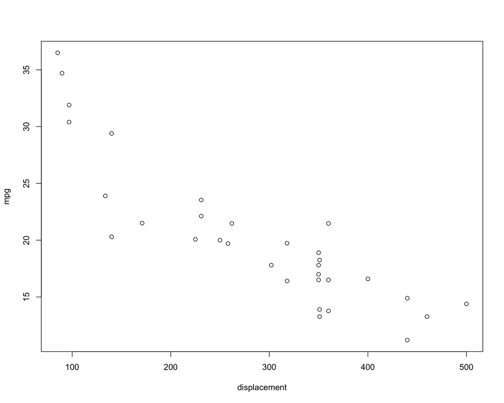

```r
library(MPV)
plot(table.b3$x1, table.b3$y, xlab = "displacement", ylab = "mpg")
```

based on the scaterplot it seems there is a nonlinear trend in the data.

**(b) Use the `xyplot()` function, and `x11` (type of transmission) as a `group` variable. Is a linear model reasonable for these data?**

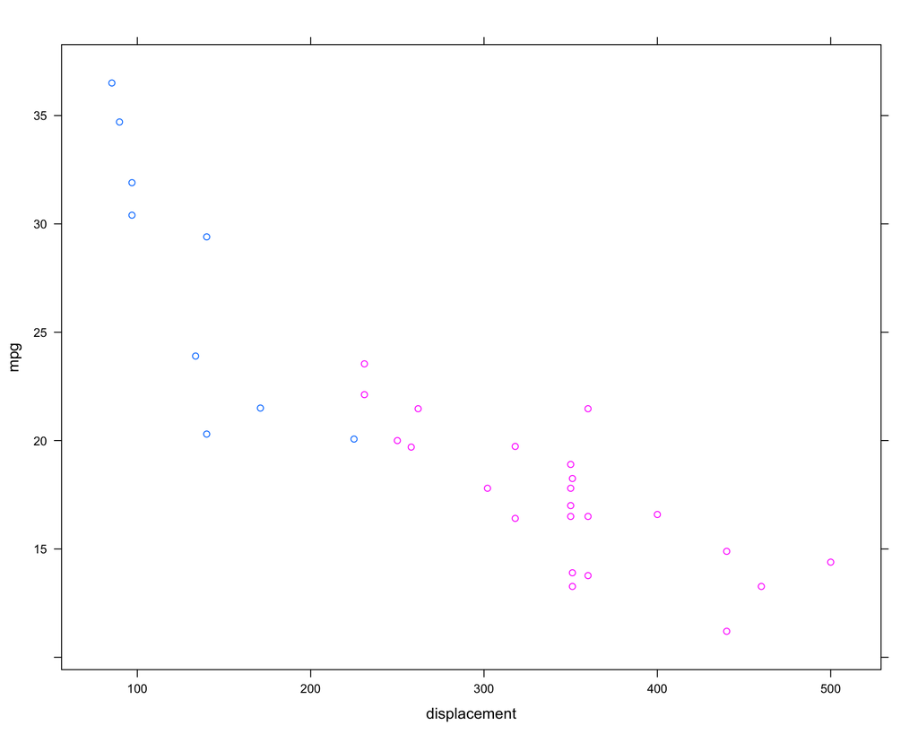

```r
library(lattice)
xyplot(y ~ x1, group = x11, xlab = "displacement", ylab = "mpg", data = table.b3)
```

two different trend with two diffrent varainces, so its not recommended to capture the pattern in data using just a simple linear model.

**(c) Fit the model relating `y` to `x1` and `x11` which gives two lines having possibly different slopes and intercepts. Check the diagnostics. Are there any influential observations? Are there any influential outliers?**

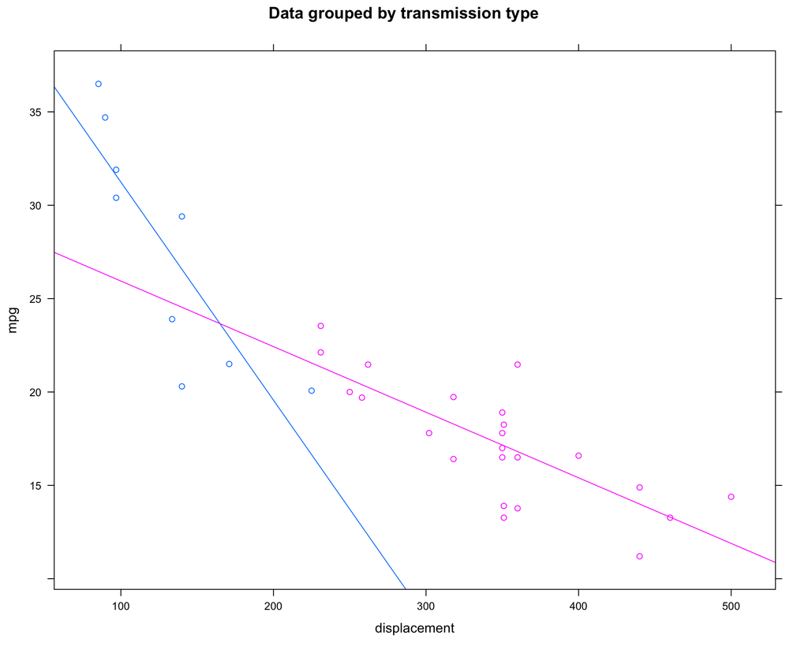

```r
xyplot(y ~ x1, group = x11, xlab = "displacement", ylab = "mpg", main = "Data grouped by transmission type", data = table.b3, type = c("p", "r"))
```

Check the diagnostics and influential outliers:

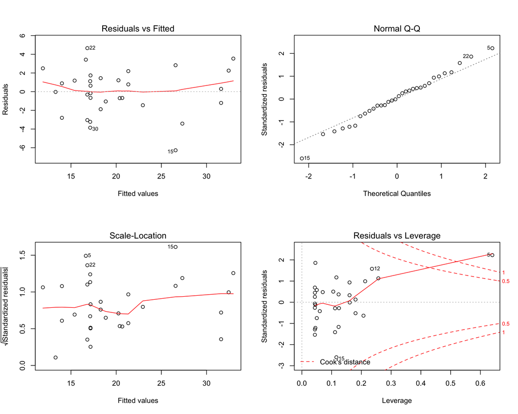

```r
par(mfrow=c(2,2))
fit <- lm(y ~ x1 * x11, data = table.b3)
plot(fit)
```

```r
par(mfrow=c(1,1))
```

according to the residuals vs leverage plot, $5$ is the influential outlier which is out of cook’s distanse boundaries.

**(d) Plot the residuals against the variable `x7` (number of transmission speeds), again using `x11` as a `group` variable. Is there anything striking about this plot?**

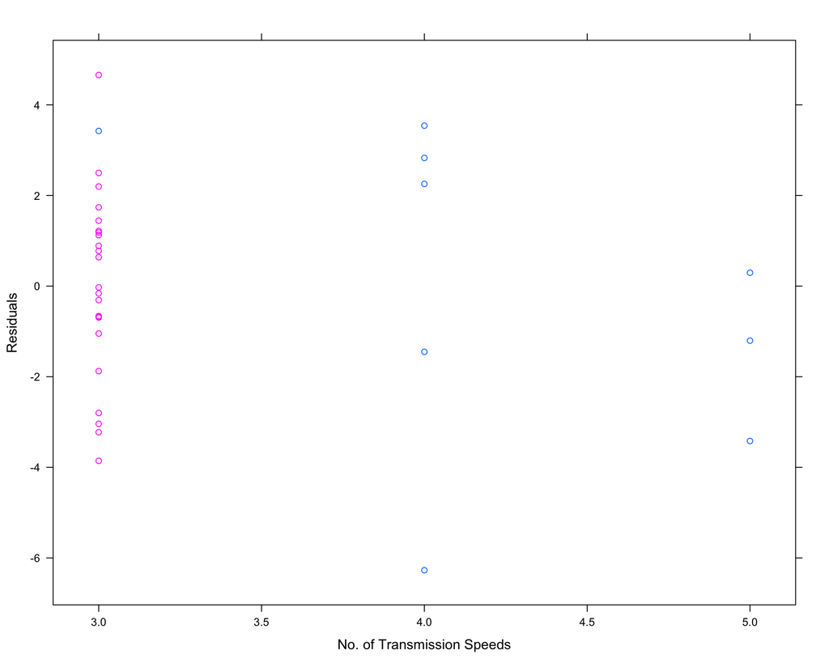

```r
xyplot(fit$residuals ~ x7, groups=x11, xlab = "No. of Transmission Speeds", ylab = "Residuals", data=table.b3)
```

the plot shows that data points are separated in a discrete way and we can distinguish different class easily. and it seems that the only outlier (blue point which is among the pink points) is 5 which we captured it in previous question.

## Exercise 11

**The following code is designed to explore effects that can result from the omission of explanatory variables:**

```r
x1 <- runif(10) # predictor which will be missing
x2 <- rbinom(10, 1, 1-x1) # observed predictor which depends on missing predictor
y <- 5*x1 + x2 + rnorm(10,sd=.1) # simulated model; coef of x2 is positive
y.lm <- lm(y ~ factor(x2)) # model fitted to observed data
coef(y.lm)
```

```
## (Intercept) factor(x2)1
##    3.515650   -1.663976
```

```r
y.lm2 <- lm(y ~ x1 + factor(x2)) # correct model
coef(y.lm2)
```

```
## (Intercept)          x1 factor(x2)1
##  0.08662874  4.90019223  0.85767511
```

**What happens if x2 is generated according to $\mathsf{x2 <- rbinom(10, 1, x1)}?$ $\mathsf{x2 <- rbinom(10, 1, .5)}$?**

Now I will use the same vector x1 and I will change x2.

1. $\mathsf{x2 <- rbinom(10, 1, x1)}$

```r
x2 <- rbinom(10, 1, x1)
y <- 5*x1 + x2 + rnorm(10,sd=.1)
y.lm <- lm(y ~ factor(x2))
coef(y.lm)
```

```
## (Intercept) factor(x2)1
##    1.259605    3.147445
```

```r
y.lm2 <- lm(y ~ x1 + factor(x2))
coef(y.lm2)
```

```
## (Intercept)          x1 factor(x2)1
## -0.08036789  5.14901047  0.90295048
```

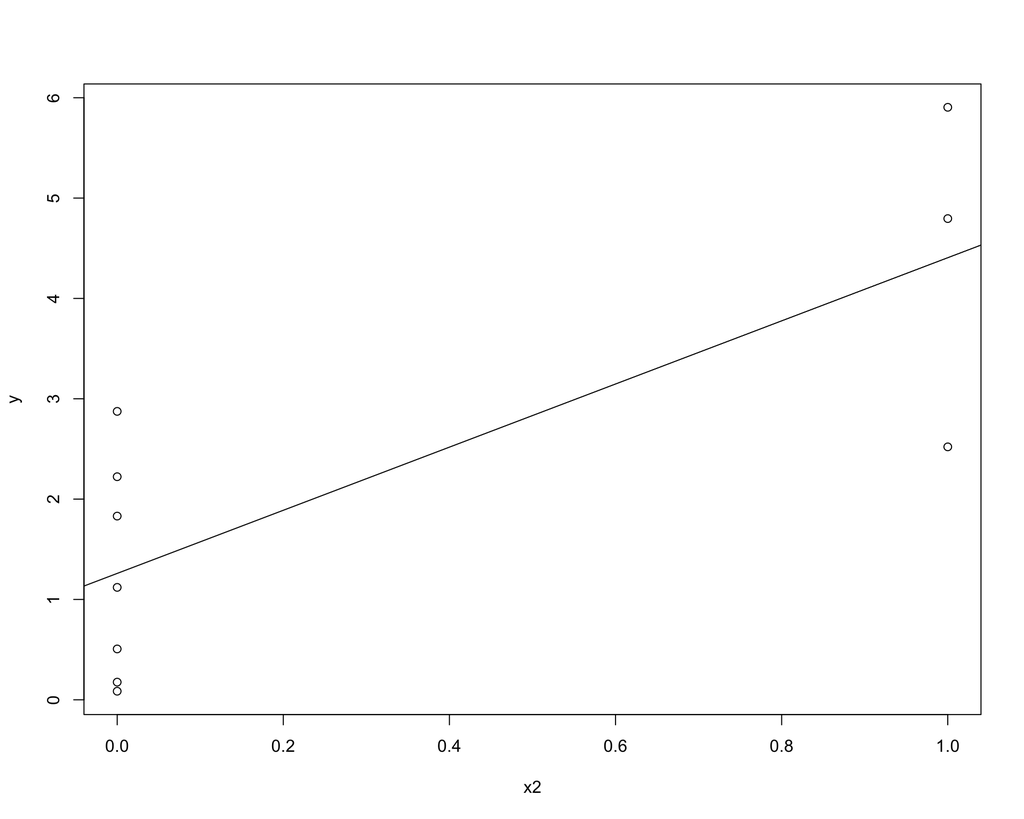

```r
plot(x2, y)
abline(y.lm)
```

In this case there is a positive correlation between the two predictors. This means that trying to fit the model without x1 will still produce a positive coefficient for x2

2. $\mathsf{x2 <- rbinom(10, 1, .5)}$

```r
x2 <- rbinom(10, 1, .5)
y <- 5*x1 + x2 + rnorm(10,sd=.1)
y.lm <- lm(y ~ factor(x2))
coef(y.lm)
```

```
## (Intercept) factor(x2)1
##   0.8872486   3.1298111
```

```r
y.lm2 <- lm(y ~ x1 + factor(x2))
coef(y.lm2)
```

```
##  (Intercept)           x1  factor(x2)1
## 0.0002788082 4.9838641848 1.0062567196
```

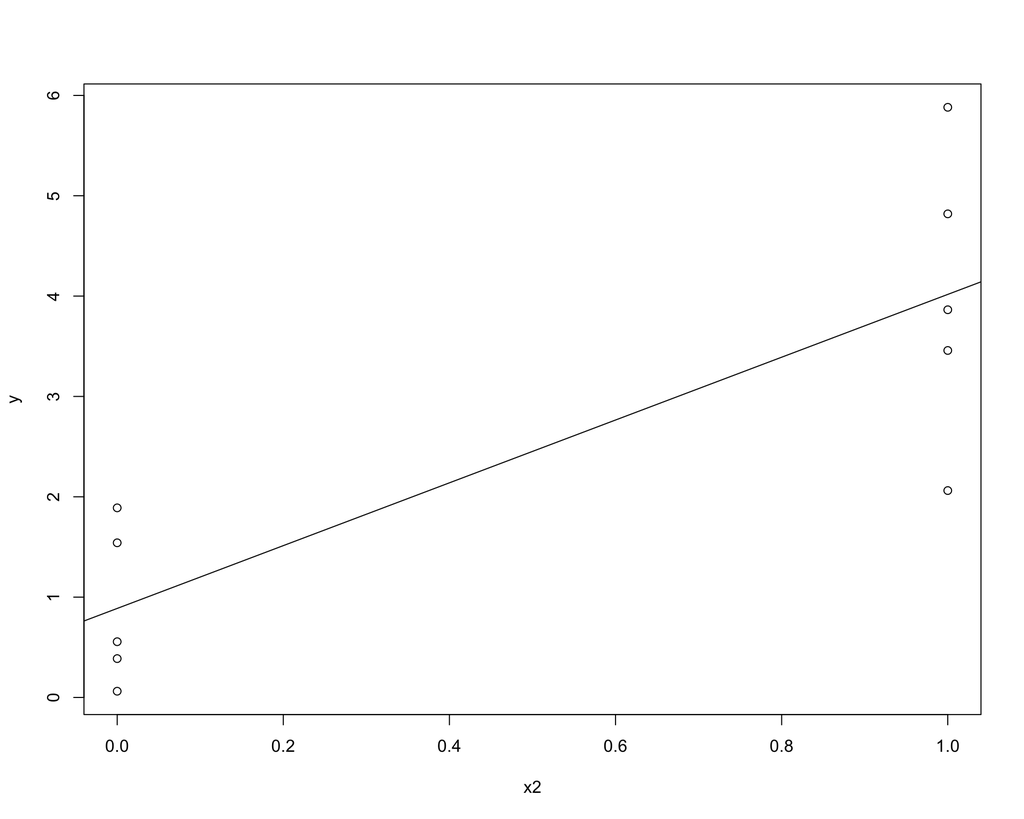

```r
plot(x2, y)
abline(y.lm)
```

Here there is no correlation between the two predictors. The prediction could vary considerably if we take into account only x2. When variables or factors are omitted from models, values of the outcome variable are as far as possible accounted for using those that remain.

# Chapter 8

## Exercise 1

**The following table shows numbers of occasions when inhibition (i.e., no ﬂow of current across a membrane) occurred within 120 s, for different concentrations of the protein peptide-C. The outcome $\mathbf{yes}$ implies that inhibition has occurred.**

| $\mathrm{conc}$ | 0.1 | 0.5 | 1 | 10 | 20 | 30 | 50 | 70 | 80 | 100 | 150 |
| --- | --- | --- | --- | --- | --- | --- | --- | --- | --- | --- | --- |
| $\mathrm{no}$ | 7 | 1 | 10 | 9 | 2 | 9 | 13 | 1 | 1 | 4 | 3 |
| $\mathrm{yes}$ | 0 | 0 | 3 | 4 | 0 | 6 | 7 | 0 | 0 | 1 | 7 |

Use logistic regression to model the probability of inhibition as a function of protein concentration.

First of all I build the dataframe, calculating also the proportion of $\mathbf{yes}$

```r
inhib <- data.frame(
  conc = c (0.1, 0.5, 1, 10, 20, 30, 50, 70, 80, 100, 150),
  no = c(7, 1, 10, 9, 2, 9, 13, 1, 1, 4, 3),
  yes = c(0, 0, 3, 4, 0, 6, 7, 0, 0, 1, 7),
  stringsAsFactors = FALSE
)

inhib$total <- apply(inhib[, c("no","yes")], 1 , sum)
inhib$prop <- inhib$yes/inhib$total

print(inhib)
```

```
##     conc no yes total      prop
## 1    0.1  7   0     7 0.0000000
## 2    0.5  1   0     1 0.0000000
## 3    1.0 10   3    13 0.2307692
## 4   10.0  9   4    13 0.3076923
## 5   20.0  2   0     2 0.0000000
## 6   30.0  9   6    15 0.4000000
## 7   50.0 13   7    20 0.3500000
## 8   70.0  1   0     1 0.0000000
## 9   80.0  1   0     1 0.0000000
## 10 100.0  4   1     5 0.2000000
## 11 150.0  3   7    10 0.7000000
```

Then I use logistic regression to model the proportion of $\mathbf{yes}$ using $\mathbf{conc}$ as predictor

```r
inhib.logit <- glm(prop ~ conc, family=binomial(link="logit"),weights=total, data=inhib)

summary(inhib.logit)
```

```
##
## Call:
## glm(formula = prop ~ conc, family = binomial(link = "logit"),
##     data = inhib, weights = total)
##
## Deviance Residuals:
##     Min       1Q   Median       3Q      Max
## -1.8159  -1.0552  -0.6878   0.3667   1.0315
##
## Coefficients:
##             Estimate Std. Error z value Pr(>|z|)
## (Intercept) -1.32701    0.33837  -3.922 8.79e-05 ***
## conc         0.01215    0.00496   2.450   0.0143 *
## ---
## Signif. codes:  0 '***' 0.001 '**' 0.01 '*' 0.05 '.' 0.1 ' ' 1
##
## (Dispersion parameter for binomial family taken to be 1)
##
##     Null deviance: 16.683  on 10  degrees of freedom
## Residual deviance: 10.389  on  9  degrees of freedom
## AIC: 30.988
##
## Number of Fisher Scoring iterations: 4
```

However with such a small sample size, a convincing check of the adequacy of the model is hard.

## Exercise 2

**In the data set (an artificial one of 3121 patients, that is similar to a subset of the data analyzed in Stiell et al., 2001) `minor.head.injury`, obtain a logistic regression model relating `clinically.important.brain.injury` to other variables. Patients whose risk is sufficiently high will be sent for CT (computed tomography). Using a risk threshold of 0.025 (2.5%), turn the result into a decision rule for use of CT.**

```r
library(DAAG)

# data splitting
size <- nrow(head.injury)
train <- head.injury[1:size * 0.8,]
test <- head.injury[(size * 0.8 + 1):size,]
# Fit the model
injury.fit <- glm(clinically.important.brain.injury ~ ., data=train, family=binomial)
summary(injury.fit)
```

```
##
## Call:
## glm(formula = clinically.important.brain.injury ~ ., family = binomial,
##     data = train)
##
## Deviance Residuals:
##     Min       1Q   Median       3Q      Max
## -2.4639  -0.3155  -0.1948  -0.1324   3.0793
##
## Coefficients:
##                       Estimate Std. Error z value Pr(>|z|)
## (Intercept)            -4.7322     0.1732 -27.322  < 2e-16 ***
## age.65                  1.3973     0.1857   7.525 5.27e-14 ***
## amnesia.before          0.7767     0.1771   4.386 1.15e-05 ***
## basal.skull.fracture    2.0333     0.2176   9.344  < 2e-16 ***
## GCS.decrease           -0.1106     0.4088  -0.271    0.787
## GCS.13                  1.2582     0.2806   4.484 7.32e-06 ***
## GCS.15.2hours           2.0617     0.1710  12.057  < 2e-16 ***
## high.risk               1.2760     0.1633   7.815 5.49e-15 ***
## loss.of.consciousness   0.9800     0.2023   4.844 1.27e-06 ***
## open.skull.fracture     0.7957     0.3168   2.512    0.012 *
## vomiting                1.3942     0.2003   6.961 3.39e-12 ***
## ---
## Signif. codes:  0 '***' 0.001 '**' 0.01 '*' 0.05 '.' 0.1 ' ' 1
##
## (Dispersion parameter for binomial family taken to be 1)
##
##     Null deviance: 1751.2  on 3119  degrees of freedom
## Residual deviance: 1134.2  on 3109  degrees of freedom
## AIC: 1156.2
##
## Number of Fisher Scoring iterations: 6
```

variable `GCS.decrease` with a large p-value can be removed from the model

```r
# Fit a new model
injury.fit <- glm(clinically.important.brain.injury ~ . - GCS.decrease, data=train, family=binomial)
summary(injury.fit)
```

```
##
## Call:
## glm(formula = clinically.important.brain.injury ~ . - GCS.decrease,
##     family = binomial, data = train)
##
## Deviance Residuals:
##     Min       1Q   Median       3Q      Max
## -2.4724  -0.3155  -0.1948  -0.1326   3.0785
##
## Coefficients:
##                       Estimate Std. Error z value Pr(>|z|)
## (Intercept)            -4.7299     0.1729 -27.350  < 2e-16 ***
## age.65                  1.3944     0.1854   7.521 5.42e-14 ***
## amnesia.before          0.7750     0.1770   4.379 1.19e-05 ***
## basal.skull.fracture    2.0218     0.2134   9.476  < 2e-16 ***
## GCS.13                  1.2574     0.2805   4.483 7.35e-06 ***
## GCS.15.2hours           2.0580     0.1704  12.076  < 2e-16 ***
## high.risk               1.2733     0.1630   7.814 5.56e-15 ***
## loss.of.consciousness   0.9799     0.2023   4.843 1.28e-06 ***
## open.skull.fracture     0.7915     0.3165   2.501   0.0124 *
## vomiting                1.3904     0.1999   6.956 3.49e-12 ***
## ---
## Signif. codes:  0 '***' 0.001 '**' 0.01 '*' 0.05 '.' 0.1 ' ' 1
##
## (Dispersion parameter for binomial family taken to be 1)
##
##     Null deviance: 1751.2  on 3119  degrees of freedom
## Residual deviance: 1134.3  on 3110  degrees of freedom
## AIC: 1154.3
##
## Number of Fisher Scoring iterations: 6
```

```r
# predict the probabilities for the test set
probs <- predict(injury.fit, test, type = "response")
# prediction on the test set based on the risk threshold of 0.025
predicts <- ifelse(probs > 0.025, 1, 0)
# predicted vs actual results
p.vs.a <- table(actual=test$clinically.important.brain.injury, predicted=predicts)
print(p.vs.a)
```

```
##       predicted
## actual   0   1
##      0 306 265
##      1   6  47
```

## Exercise 3

**Consider again the moths data set of Section 8.4.**

**(a) What happens to the standard error estimates when the `poisson` family is used in `glm()` instead of the `quasipoisson` family?**

**(b) Analyze the `P` moths, in the same way as the `A` moths were analyzed. Comment on the effect of transect length.**

```r
library(DAAG)
# Results for the quasipoisson family
moths$habitat <- relevel(moths$habitat, ref="Lowerside")
summary(A.glm.quasipoisson <- glm(A~habitat + log(meters) ,family = quasipoisson, data = moths))
```

```
##
## Call:
## glm(formula = A ~ habitat + log(meters), family = quasipoisson,
##     data = moths)
##
## Deviance Residuals:
##     Min       1Q   Median       3Q      Max
## -3.5562  -1.4635  -0.0007   0.9248   3.0822
##
## Coefficients:
##                    Estimate Std. Error t value Pr(>|t|)
## (Intercept)         1.20981    0.45530   2.657   0.0122 *
## habitatBank       -16.90566 2096.58841  -0.008   0.9936
## habitatDisturbed   -1.28323    0.64737  -1.982   0.0561 .
## habitatNEsoak      -0.82170    0.53700  -1.530   0.1358
## habitatNWsoak       1.56243    0.33426   4.674 5.11e-05 ***
## habitatSEsoak       0.06206    0.38515   0.161   0.8730
## habitatSWsoak       0.23143    0.47807   0.484   0.6316
## habitatUpperside   -0.16234    0.58429  -0.278   0.7829
## log(meters)         0.12917    0.15278   0.845   0.4041
## ---
## Signif. codes:  0 '***' 0.001 '**' 0.01 '*' 0.05 '.' 0.1 ' ' 1
##
## (Dispersion parameter for quasipoisson family taken to be 2.700801)
##
##     Null deviance: 257.108  on 40  degrees of freedom
## Residual deviance:  93.991  on 32  degrees of freedom
## AIC: NA
##
## Number of Fisher Scoring iterations: 13
```

1. Since the dispersion parameter estimate in the case of the quasipoisson is $2.70$ we expect that standard errors obtained using this family were incresaed by a factor $\sqrt{2.70}=1.64$ when compared with the ones we will obtain using the Poisson family. Let’s verify this:

```r
# Results for the poisson family
summary(A.glm.poisson <- glm(A~habitat + log(meters) ,family = poisson, data = moths))
```

```
##
## Call:
## glm(formula = A ~ habitat + log(meters), family = poisson, data = moths)
##
## Deviance Residuals:
##     Min       1Q   Median       3Q      Max
## -3.5562  -1.4635  -0.0007   0.9248   3.0822
##
## Coefficients:
##                    Estimate Std. Error z value Pr(>|z|)
## (Intercept)         1.20981    0.27705   4.367 1.26e-05 ***
## habitatBank       -16.90566 1275.75387  -0.013  0.98943
## habitatDisturbed   -1.28323    0.39392  -3.258  0.00112 **
## habitatNEsoak      -0.82170    0.32676  -2.515  0.01191 *
## habitatNWsoak       1.56243    0.20340   7.682 1.57e-14 ***
## habitatSEsoak       0.06206    0.23436   0.265  0.79114
## habitatSWsoak       0.23143    0.29090   0.796  0.42628
## habitatUpperside   -0.16234    0.35554  -0.457  0.64796
## log(meters)         0.12917    0.09297   1.389  0.16471
## ---
## Signif. codes:  0 '***' 0.001 '**' 0.01 '*' 0.05 '.' 0.1 ' ' 1
##
## (Dispersion parameter for poisson family taken to be 1)
##
##     Null deviance: 257.108  on 40  degrees of freedom
## Residual deviance:  93.991  on 32  degrees of freedom
## AIC: 226.71
##
## Number of Fisher Scoring iterations: 13
```

We can now compare the standard error values between the first and the second case, we expect that:

$$\frac{\text{SE}_{quasipoisson}}{\text{SE}_{poisson}}=1.64$$

```r
# Comparison of the standard errors obtained in the two cases
SE.quasipoisson <- (summary(A.glm <- glm(A~habitat + log(meters) ,family = quasipoisson, data = moths))$coefficients)[,2]
SE.poisson <- (summary(A.glm2 <- glm(A~habitat + log(meters) ,family = poisson, data = moths))$coefficients)[,2]
SE.quasipoisson/SE.poisson
```

```
##      (Intercept)      habitatBank habitatDisturbed    habitatNEsoak
##         1.643411         1.643411         1.643411         1.643411
##    habitatNWsoak    habitatSEsoak    habitatSWsoak habitatUpperside
##         1.643411         1.643411         1.643411         1.643411
##      log(meters)
##         1.643411
```

The results agree with our prediction.

2. Since we are asked to analyse the P moths in the same way as the A moths were analysed we keep `lowerside` as the reference:

```r
library(DAAG)
# Display the data
rbind(Number=table(moths[, 4]), sapply(split(moths[, -4], moths$habitat),apply, 2, sum))
```

```
##        Lowerside Bank Disturbed NEsoak NWsoak SEsoak SWsoak Upperside
## Number         9    1         7      6      3      7      3         5
## meters       191   21        49    254     65    193    116       952
## A             41    0         8     14     71     37     20        28
## P             17    4        33     14     19      6     48         8
```

```r
# Change Reference level
moths$habitat <- relevel(moths$habitat, ref="Lowerside")
# Results of the GLM
summary(P.glm <- glm(P ~ habitat + log(meters),  family=quasipoisson, data = moths))
```

```
##
## Call:
## glm(formula = P ~ habitat + log(meters), family = quasipoisson,
##     data = moths)
##
## Deviance Residuals:
##     Min       1Q   Median       3Q      Max
## -2.9479  -1.3155  -0.4167   0.5660   2.9719
##
## Coefficients:
##                  Estimate Std. Error t value Pr(>|t|)
## (Intercept)       -0.8608     0.6745  -1.276  0.21105
## habitatBank        0.5569     0.8837   0.630  0.53301
## habitatDisturbed   1.4364     0.5172   2.777  0.00909 **
## habitatNEsoak     -0.3211     0.5844  -0.549  0.58651
## habitatNWsoak      1.0106     0.5309   1.904  0.06598 .
## habitatSEsoak     -1.0697     0.7560  -1.415  0.16673
## habitatSWsoak      1.6383     0.4582   3.575  0.00113 **
## habitatUpperside  -1.5773     0.7757  -2.033  0.05038 .
## log(meters)        0.5552     0.1759   3.157  0.00347 **
## ---
## Signif. codes:  0 '***' 0.001 '**' 0.01 '*' 0.05 '.' 0.1 ' ' 1
##
## (Dispersion parameter for quasipoisson family taken to be 2.527554)
##
##     Null deviance: 217.819  on 40  degrees of freedom
## Residual deviance:  76.924  on 32  degrees of freedom
## AIC: NA
##
## Number of Fisher Scoring iterations: 6
```

So our model will be:
$$\log(\text{expected number of moths})= -0.8608 + 0.5552 \log(\text{meters})+\text{habitat}$$

$$\text{expected number of moths}=0.4228 \times \text{meters}^{0.5552} \times e^{habitat}$$

```r
# compute the expected number of moths
expected <- vector()
for (i in 1:7) {
  expected[i]<- 0.4228 * ((rbind(Number=table(moths[, 4]), sapply(split(moths[, -4], moths$habitat),apply, 2, sum)))[2,i+1])^{0.5552}*exp(((summary(P.glm <- glm(P ~ habitat + log(meters),  family=quasipoisson, data = moths))
)$coefficients)[i+1,1])
}
expected
```

```
## [1]  4.000385 15.428864  6.635114 11.791409  2.694681 30.466455  3.934180
```

So the highest numbers are for `SWsoak` and `Disturbed`.

Note that in this case the coefficient `log(meters)` is statistically significant, the number of moths increases with the transect lenght by a factor $e^{0.5552}=1.7422$.

## Exercise 6

**As in the previous exercise, the function poissonsim() allows for experimentation with Poisson regression. In particular, poissonsim() can be used to simulate Poisson responses with log-rates equal to a + bx, where a and b are fixed values by default.**

### (a)

**Simulate 100 Poisson responses using the model log λ = 2 − 4x for x = 0, 0.01, 0.02 . . . , 1.0. Fit a Poisson regression model to these data, and compare the estimated coefficients with the true coefficients. How well does the estimated model predict future observations?**

```r
x <- seq(0,1,0.01)
pois.data <- poissonsim(x) #a and b are already by default 2 and -4
pois.lm <- glm(y ~ x, data = pois.data, family = poisson)
pois.lm$coefficients #a and b are pretty close to the one we used to generate data
```

```
## (Intercept)           x
##    2.071727   -4.087912
```

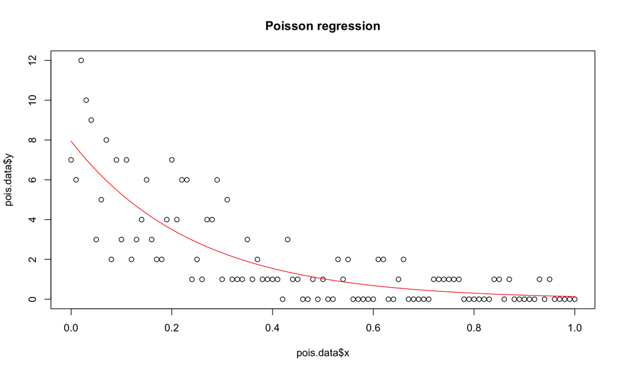

```r
par(mfrow=c(1,1))
plot(pois.data$x, pois.data$y, main = "Poisson regression")
lines(pois.data$x, as.vector(pois.lm$fitted.values), col ="red")
```

Apparently the model gives really good predictions, since the coefficients are pretty much the same of the ones of the true model.

2. **Simulate 100 Poisson responses using the model log λ = 2 − bx where b is normally distributed with mean 4 and standard deviation 5. [Use the argument slope.sd=5 in the poissonsim() function.] How do the results using the poisson and quasipoisson families differ?**

```r
pois.data.gauss <- poissonsim(x, slope.sd = 5)
pois.gauss.lm <- glm(y ~ x, data = pois.data.gauss, family = poisson)
quasipois.gauss.lm <- glm(y ~ x, data = pois.data.gauss, family = quasipoisson)
summary(pois.gauss.lm)
```

```
##
## Call:
## glm(formula = y ~ x, family = poisson, data = pois.data.gauss)
##
## Deviance Residuals:
##    Min      1Q  Median      3Q     Max
## -7.906  -4.694  -2.785   0.537  37.624
##
## Coefficients:
##             Estimate Std. Error z value Pr(>|z|)
## (Intercept)  1.32255    0.07553   17.51   <2e-16 ***
## x            2.11958    0.10531   20.13   <2e-16 ***
## ---
## Signif. codes:  0 '***' 0.001 '**' 0.01 '*' 0.05 '.' 0.1 ' ' 1
##
## (Dispersion parameter for poisson family taken to be 1)
##
##     Null deviance: 4224.9  on 100  degrees of freedom
## Residual deviance: 3774.1  on  99  degrees of freedom
## AIC: 4037.9
##
## Number of Fisher Scoring iterations: 7
```

```r
summary(quasipois.gauss.lm)
```

```
##
## Call:
## glm(formula = y ~ x, family = quasipoisson, data = pois.data.gauss)
##
## Deviance Residuals:
##    Min      1Q  Median      3Q     Max
## -7.906  -4.694  -2.785   0.537  37.624
##
## Coefficients:
##             Estimate Std. Error t value Pr(>|t|)
## (Intercept)   1.3226     0.6800   1.945   0.0546 .
## x             2.1196     0.9481   2.236   0.0276 *
## ---
## Signif. codes:  0 '***' 0.001 '**' 0.01 '*' 0.05 '.' 0.1 ' ' 1
##
## (Dispersion parameter for quasipoisson family taken to be 81.04783)
##
##     Null deviance: 4224.9  on 100  degrees of freedom
## Residual deviance: 3774.1  on  99  degrees of freedom
## AIC: NA
##
## Number of Fisher Scoring iterations: 7
```

Here the predictions of our coefficients are way off: the only difference in between using a poisson or a quasi poisson family for the regression problem, is that the variance of the estimates is way higher with the quasipoisson. Hence we should conclude that when we suspect that the $\lambda$ parameter for the poisson distribution already has a lot of variance, then we should use a quasi poisson regression so that the final variance doesn’t get underestimated.